# NLP Analysis

Author

GROUP IV

## Section D - Key Findings Summary

[output not shown]

[output cut: 55 more lines]

[output not shown]

## Section E - NLP Analysis — Job Description Insights

#This section extends the analysis beyond structured variables by applying Natural Language Processing (NLP) techniques to job descriptions. #The goal is to extract key skills, understand employer requirements, and identify hidden patterns in unstructured text data.

|  | word | count |
| --- | --- | --- |
| 0 | analyst | 32636 |
| 7 | data | 27227 |
| 6 | consultant | 10382 |
| 16 | sap | 9922 |
| 2 | architect | 7414 |
| 17 | senior | 7236 |
| 14 | oracle | 6893 |
| 8 | enterprise | 6669 |
| 4 | business | 6352 |
| 1 | analytics | 4866 |
| 12 | lead | 3750 |
| 19 | sr | 3562 |
| 10 | functional | 3280 |
| 11 | intelligence | 3142 |
| 5 | cloud | 2808 |
| 15 | remote | 2686 |
| 9 | erp | 2200 |
| 3 | associate | 2196 |
| 13 | management | 2083 |
| 18 | specialist | 1787 |

##1. Word Frequency Table ##This table shows the most frequently used words in the job posting text. The most common words are analyst, data, consultant, SAP, architect, and senior. This suggests that the dataset is heavily focused on business analytics, enterprise systems, consulting, and technical business roles. Words such as SAP, Oracle, ERP, and enterprise also indicate that many employers are looking for candidates with enterprise software and business systems knowledge, not only general data skills.

|  | word | score |
| --- | --- | --- |
| 0 | analyst | 0.260162 |
| 7 | data | 0.240704 |
| 16 | sap | 0.097445 |
| 6 | consultant | 0.091892 |
| 2 | architect | 0.079597 |
| 17 | senior | 0.068277 |
| 8 | enterprise | 0.067293 |
| 14 | oracle | 0.062714 |
| 4 | business | 0.058099 |
| 1 | analytics | 0.052049 |
| 12 | lead | 0.039042 |
| 19 | sr | 0.037909 |
| 10 | functional | 0.032813 |
| 11 | intelligence | 0.031876 |
| 15 | remote | 0.029175 |
| 5 | cloud | 0.026618 |
| 3 | associate | 0.025660 |
| 9 | erp | 0.024603 |
| 13 | management | 0.022844 |
| 18 | specialist | 0.020987 |

##2. TF-IDF Keyword Table ##The TF-IDF results are similar to the word frequency results, but they give more weight to words that are important across the text rather than just repeated often. Analyst and data still have the highest scores, which confirms that analytics-related roles dominate the dataset. The high scores for SAP, consultant, architect, and enterprise show that specialized business technology skills are important in this job market. Compared with simple word counts, TF-IDF gives a better sense of which terms are more meaningful for understanding job descriptions.

|  | skill | count |
| --- | --- | --- |
| 1 | sql | 14 |
| 6 | communication | 9 |
| 2 | excel | 2 |
| 0 | python | 1 |
| 5 | power bi | 1 |
| 4 | tableau | 0 |
| 3 | machine learning | 0 |

##3. Skill Keyword Count and Bar Chart ##The skill keyword chart shows that SQL appears most often, followed by communication and Excel. This means employers are not only looking for technical ability, but also business communication and reporting skills. Python, Power BI, Tableau, and machine learning appear less frequently in this result, which may suggest that many postings are more focused on analytics, database querying, and business reporting than advanced machine learning. For students, SQL and communication should be treated as core employability skills.

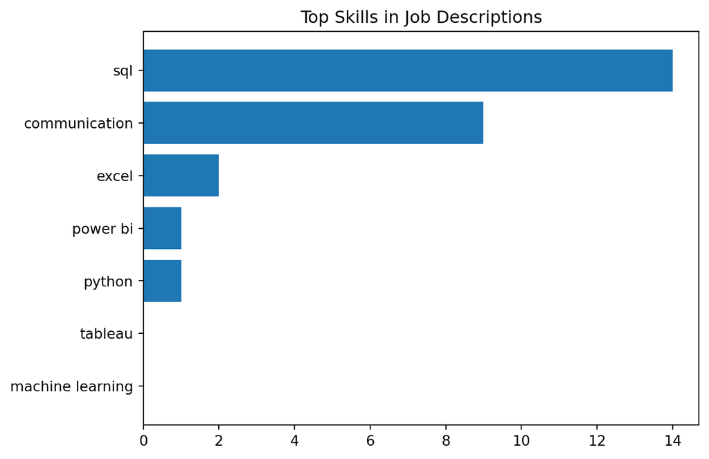

|  | has_python | SALARY_MID |
| --- | --- | --- |
| 0 | False | 114379.306499 |
| 1 | True | 106080.000000 |